# Exploratory_FordGoBike

[figure not shown]

- Introduction
- Data Wrangling
  - Gathering Data
  - Assessing Data
  - Cleaning Data
- Exploratory Data Analysis
- Summary

## Introduction

This data set includes information about individual rides made in a bike-sharing system covering the greater San Francisco Bay Area. On June 28, 2017, the system officially launched as Ford GoBike in a partnership with Ford Motor Company.

Ford GoBike, like other bike share systems, consists of a fleet of specially designed, sturdy and durable bikes that are locked into a network of docking stations throughout the city. The bikes can be unlocked from one station and returned to any other station in the system, making them ideal for one-way trips. The bikes are available for use 24 hours/day, 7 days/week, 365 days/year and riders have access to all bikes in the network when they become a member or purchase a pass.

The Data Each trip is anonymized and includes:

Trip Duration (seconds)

Start Time and Date

End Time and Date

Start Station ID

Start Station Name

Start Station Latitude

Start Station Longitude

End Station ID

End Station Name

End Station Latitude

End Station Longitude

Bike ID

User Type (Subscriber or Customer – “Subscriber” = Member or “Customer” = Casual)

Member Year of Birth

Member Gender

```python
#Import Packages
import numpy as np
import pandas as pd
import datetime as dt
import matplotlib.pyplot as plt
import seaborn as sns
%matplotlib inline

sns.set (style = "darkgrid")
```

## Data Wrangling

- 1. Gathering Data In this project, i have downloaded a provided dataset by Lyft https://s3.amazonaws.com/baywheels-data/index.html for bike sharing data in the greater San Francisco Bay Area at July 2019

```python
#Load FordGobike Dataset for July 2019
df = pd.read_csv('201907-baywheels-tripdata.csv')
```

- 2. Assessing Data

```python
#Visually Check
df.head(10)
```

|  | duration_sec | start_time | end_time | start_station_id | start_station_name | start_station_latitude | start_station_longitude | end_station_id | end_station_name | end_station_latitude | end_station_longitude | bike_id | user_type | member_birth_year | member_gender | bike_share_for_all_trip | Unnamed: 16 |
| --- | --- | --- | --- | --- | --- | --- | --- | --- | --- | --- | --- | --- | --- | --- | --- | --- | --- |
| 0 | 85457 | 2019-07-31 09:25:37.3410 | 2019-08-01 09:09:54.6000 | 36.0 | Folsom St at 3rd St | 37.783830 | -122.398870 | 344.0 | 16th St Depot | 37.766349 | -122.396292 | 3491 | Customer | NaN | NaN | No | NaN |
| 1 | 53831 | 2019-07-31 18:00:10.2940 | 2019-08-01 08:57:21.9750 | 139.0 | Garfield Square (25th St at Harrison St) | 37.751017 | -122.411901 | 133.0 | Valencia St at 22nd St | 37.755213 | -122.420975 | 2457 | Customer | NaN | NaN | No | NaN |
| 2 | 33674 | 2019-07-31 22:52:29.7910 | 2019-08-01 08:13:44.0100 | 155.0 | Emeryville Public Market | 37.840521 | -122.293528 | 155.0 | Emeryville Public Market | 37.840521 | -122.293528 | 2750 | Customer | 1985.0 | Male | No | NaN |
| 3 | 34546 | 2019-07-31 21:59:34.2580 | 2019-08-01 07:35:21.0440 | 41.0 | Golden Gate Ave at Polk St | 37.781270 | -122.418740 | 73.0 | Pierce St at Haight St | 37.771793 | -122.433708 | 303 | Subscriber | 1988.0 | Female | No | NaN |
| 4 | 40244 | 2019-07-31 20:20:37.5420 | 2019-08-01 07:31:21.6060 | 339.0 | Jackson St at 11th St | 37.800002 | -122.266438 | 233.0 | 4th Ave at E 12th St (Temporary Location) | 37.795913 | -122.255547 | 2637 | Subscriber | 1988.0 | Male | No | NaN |
| 5 | 14078 | 2019-07-31 20:48:50.6440 | 2019-08-01 00:43:28.6570 | 250.0 | North Berkeley BART Station | 37.873558 | -122.283093 | 271.0 | San Pablo Park | 37.855783 | -122.283127 | 1739 | Customer | NaN | NaN | No | NaN |
| 6 | 1094 | 2019-07-31 23:58:10.6320 | 2019-08-01 00:16:25.5940 | 198.0 | Snow Park | 37.807813 | -122.264496 | 188.0 | Dover St at 57th St | 37.842630 | -122.267738 | 1208 | Subscriber | 1969.0 | Male | No | NaN |
| 7 | 563 | 2019-07-31 23:58:59.6200 | 2019-08-01 00:08:23.5350 | 66.0 | 3rd St at Townsend St | 37.778742 | -122.392741 | 345.0 | Hubbell St at 16th St | 37.766483 | -122.398279 | 1337 | Customer | NaN | NaN | No | NaN |
| 8 | 678 | 2019-07-31 23:56:56.5870 | 2019-08-01 00:08:15.5280 | 66.0 | 3rd St at Townsend St | 37.778742 | -122.392741 | 370.0 | Jones St at Post St | 37.787327 | -122.413278 | 3275 | Subscriber | 1989.0 | Male | No | NaN |
| 9 | 870 | 2019-07-31 23:53:08.3840 | 2019-08-01 00:07:38.6300 | 133.0 | Valencia St at 22nd St | 37.755213 | -122.420975 | 85.0 | Church St at Duboce Ave | 37.770083 | -122.429156 | 3247 | Subscriber | 1982.0 | Male | No | NaN |

```python
df.tail(10)
```

|  | duration_sec | start_time | end_time | start_station_id | start_station_name | start_station_latitude | start_station_longitude | end_station_id | end_station_name | end_station_latitude | end_station_longitude | bike_id | user_type | member_birth_year | member_gender | bike_share_for_all_trip | Unnamed: 16 |
| --- | --- | --- | --- | --- | --- | --- | --- | --- | --- | --- | --- | --- | --- | --- | --- | --- | --- |
| 199862 | 1072 | 2019-07-20 12:42:19 | 2019-07-20 13:00:12 | NaN | NaN | 37.885602 | -122.269899 | NaN | NaN | 37.846520 | -122.252068 | 438085 | Subscriber | 1986.0 | M | NaN | app |
| 199863 | 2354 | 2019-07-14 18:31:19 | 2019-07-14 19:10:34 | NaN | NaN | 37.885752 | -122.267697 | 156.0 | Stanford Ave at Hollis St | 37.838443 | -122.288665 | 399523 | Subscriber | 1977.0 | M | NaN | app |
| 199864 | 1601 | 2019-07-28 11:30:50 | 2019-07-28 11:57:31 | NaN | NaN | 37.885753 | -122.267630 | NaN | NaN | 37.859788 | -122.286398 | 466175 | Subscriber | 1998.0 | M | NaN | app |
| 199865 | 101 | 2019-07-28 15:12:28 | 2019-07-28 15:14:09 | NaN | NaN | 37.885773 | -122.267646 | NaN | NaN | 37.885779 | -122.267741 | 572370 | Customer | NaN | NaN | NaN | app |
| 199866 | 630 | 2019-07-25 14:00:17 | 2019-07-25 14:10:48 | NaN | NaN | 37.885792 | -122.267613 | NaN | NaN | 37.868089 | -122.278545 | 353655 | Subscriber | 1992.0 | F | NaN | app |
| 199867 | 850 | 2019-07-28 11:02:37 | 2019-07-28 11:16:48 | NaN | NaN | 37.888052 | -122.256561 | NaN | NaN | 37.870571 | -122.266337 | 148227 | Subscriber | 1995.0 | F | NaN | app |
| 199868 | 589 | 2019-07-30 09:33:52 | 2019-07-30 09:43:41 | NaN | NaN | 37.888215 | -122.266832 | NaN | NaN | 37.869662 | -122.268208 | 547361 | Subscriber | 1981.0 | M | NaN | app |
| 199869 | 370 | 2019-07-26 12:50:49 | 2019-07-26 12:56:59 | NaN | NaN | 37.891297 | -122.279522 | 254.0 | Vine St at Shattuck Ave | 37.880222 | -122.269592 | 896256 | Subscriber | 1964.0 | F | NaN | clipper |
| 199870 | 593 | 2019-07-30 20:26:47 | 2019-07-30 20:36:41 | NaN | NaN | 37.892187 | -122.272765 | NaN | NaN | 37.881075 | -122.270206 | 440004 | Subscriber | NaN | ? | NaN | app |
| 199871 | 1716 | 2019-07-31 06:55:02 | 2019-07-31 07:23:39 | NaN | NaN | 37.895300 | -122.269339 | 409.0 | 2100 Powell St | 37.839543 | -122.298718 | 512019 | Subscriber | 1983.0 | F | NaN | app |

```python
#Assess Programmatically
df.info()
```

```
<class 'pandas.core.frame.DataFrame'>
RangeIndex: 199872 entries, 0 to 199871
Data columns (total 17 columns):
duration_sec               199872 non-null int64
start_time                 199872 non-null object
end_time                   199872 non-null object
start_station_id           180833 non-null float64
start_station_name         180837 non-null object
start_station_latitude     199872 non-null float64
start_station_longitude    199872 non-null float64
end_station_id             180207 non-null float64
end_station_name           180210 non-null object
end_station_latitude       199872 non-null float64
end_station_longitude      199872 non-null float64
bike_id                    199872 non-null int64
user_type                  199872 non-null object
member_birth_year          166419 non-null float64
member_gender              168796 non-null object
bike_share_for_all_trip    170248 non-null object
Unnamed: 16                29624 non-null object
dtypes: float64(7), int64(2), object(8)
memory usage: 25.9+ MB
```

```python
#Assess duplicated value
df.duplicated().any()
```

```
False
```

```python
#Assess datafram using descriptive statistics
df.describe()
```

|  | duration_sec | start_station_id | start_station_latitude | start_station_longitude | end_station_id | end_station_latitude | end_station_longitude | bike_id | member_birth_year |
| --- | --- | --- | --- | --- | --- | --- | --- | --- | --- |
| count | 199872.000000 | 180833.000000 | 199872.000000 | 199872.000000 | 180207.000000 | 199872.000000 | 199872.000000 | 199872.000000 | 166419.000000 |
| mean | 824.064831 | 142.716844 | 37.754622 | -122.326444 | 139.571326 | 37.754788 | -122.325927 | 69886.316748 | 1985.174217 |
| std | 1863.564252 | 117.614975 | 0.131513 | 0.145839 | 116.695149 | 0.131478 | 0.145334 | 186190.353718 | 10.200443 |
| min | 60.000000 | 3.000000 | 37.279518 | -122.453705 | 3.000000 | 37.244987 | -122.453705 | 12.000000 | 1889.000000 |
| 25% | 361.000000 | 47.000000 | 37.769305 | -122.408915 | 43.000000 | 37.770030 | -122.407646 | 1170.000000 | 1980.000000 |
| 50% | 576.000000 | 104.000000 | 37.781074 | -122.394643 | 100.000000 | 37.781650 | -122.394643 | 2261.000000 | 1988.000000 |
| 75% | 904.000000 | 238.000000 | 37.802746 | -122.269528 | 223.000000 | 37.802746 | -122.269927 | 3392.000000 | 1993.000000 |
| max | 86217.000000 | 443.000000 | 37.895300 | -121.826737 | 443.000000 | 37.912955 | -121.770006 | 996963.000000 | 2001.000000 |

Quality Issue:

- start_time and end_time should be DateTime, not an object
- Duration_sec should be converted into minutes
- breaking down the start_time and end_time to generate further details about hour, date, day-weekdays & weekend.
- User_type, member_gender, bike_share_for_all_trip can be converted to category
- bike_id, start_station_id, end_station_id should be object, not a float
- Calculating age and create bins for age group, and Round up age
- Few data shows anomaly in member_birth_year, anomaly shows member_birth_year prior 1900. this will be the outliers of age data
- In the gender_member, some of Male data is printed as 'M', Female data is printed as 'F', Other data is printed as 'O' and '?'

Tidiness Issue:

Drop the uneccessary column such as start_station_latitude, start_station_longitude, end_station_latitude, end_station_longitude, Unnamed: 16

- 3. Cleaning Data

```python
#Copy the dataset for cleaning purpose
df_clean = df.copy()
```

**Define:**

changing the inappropriate datatype

**Code:**

```python
# change start_time and end_time to timestamps
df_clean.start_time = pd.to_datetime(df_clean.start_time)
df_clean.end_time = pd.to_datetime(df_clean.end_time)

# change user_type, member_gender, bike_share_for_all_trip to category
df_clean.user_type = df_clean.user_type.astype('category')
df_clean.member_gender = df_clean.member_gender.astype('category')
df_clean.bike_share_for_all_trip = df_clean.bike_share_for_all_trip.astype('category')

# change bike_id, start_station_id, end_station_id to object
df_clean.bike_id = df_clean.bike_id.astype(str)
df_clean.start_station_id = df_clean.bike_id.astype(str)
df_clean.end_station_id = df_clean.bike_id.astype(str)
```

**Test:**

```python
df_clean.info()
```

```
<class 'pandas.core.frame.DataFrame'>
RangeIndex: 199872 entries, 0 to 199871
Data columns (total 17 columns):
duration_sec               199872 non-null int64
start_time                 199872 non-null datetime64[ns]
end_time                   199872 non-null datetime64[ns]
start_station_id           199872 non-null object
start_station_name         180837 non-null object
start_station_latitude     199872 non-null float64
start_station_longitude    199872 non-null float64
end_station_id             199872 non-null object
end_station_name           180210 non-null object
end_station_latitude       199872 non-null float64
end_station_longitude      199872 non-null float64
bike_id                    199872 non-null object
user_type                  199872 non-null category
member_birth_year          166419 non-null float64
member_gender              168796 non-null category
bike_share_for_all_trip    170248 non-null category
Unnamed: 16                29624 non-null object
dtypes: category(3), datetime64[ns](2), float64(5), int64(1), object(6)
memory usage: 21.9+ MB
```

**Define:**

Duration_sec should be converted into minutes

**Code:**

```python
#create a new column for duration_min by converting second to minute from duration_sec
df_clean['duration_min'] = df_clean['duration_sec']/60
```

**Test:**

```python
df_clean.head(5)
```

|  | duration_sec | start_time | end_time | start_station_id | start_station_name | start_station_latitude | start_station_longitude | end_station_id | end_station_name | end_station_latitude | end_station_longitude | bike_id | user_type | member_birth_year | member_gender | bike_share_for_all_trip | Unnamed: 16 | duration_min |
| --- | --- | --- | --- | --- | --- | --- | --- | --- | --- | --- | --- | --- | --- | --- | --- | --- | --- | --- |
| 0 | 85457 | 2019-07-31 09:25:37.341 | 2019-08-01 09:09:54.600 | 3491 | Folsom St at 3rd St | 37.783830 | -122.398870 | 3491 | 16th St Depot | 37.766349 | -122.396292 | 3491 | Customer | NaN | NaN | No | NaN | 1424.283333 |
| 1 | 53831 | 2019-07-31 18:00:10.294 | 2019-08-01 08:57:21.975 | 2457 | Garfield Square (25th St at Harrison St) | 37.751017 | -122.411901 | 2457 | Valencia St at 22nd St | 37.755213 | -122.420975 | 2457 | Customer | NaN | NaN | No | NaN | 897.183333 |
| 2 | 33674 | 2019-07-31 22:52:29.791 | 2019-08-01 08:13:44.010 | 2750 | Emeryville Public Market | 37.840521 | -122.293528 | 2750 | Emeryville Public Market | 37.840521 | -122.293528 | 2750 | Customer | 1985.0 | Male | No | NaN | 561.233333 |
| 3 | 34546 | 2019-07-31 21:59:34.258 | 2019-08-01 07:35:21.044 | 303 | Golden Gate Ave at Polk St | 37.781270 | -122.418740 | 303 | Pierce St at Haight St | 37.771793 | -122.433708 | 303 | Subscriber | 1988.0 | Female | No | NaN | 575.766667 |
| 4 | 40244 | 2019-07-31 20:20:37.542 | 2019-08-01 07:31:21.606 | 2637 | Jackson St at 11th St | 37.800002 | -122.266438 | 2637 | 4th Ave at E 12th St (Temporary Location) | 37.795913 | -122.255547 | 2637 | Subscriber | 1988.0 | Male | No | NaN | 670.733333 |

**Define:**

breaking down the start_time and end_time to generate further details about hour, date, day-weekdays & weekend

**Code:**

```python
#From start_time and end_time we can extract the  hour, date, day-weekdays & weekend

#create Hour for start and end
df_clean['start_time_hour']=df_clean['start_time'].dt.hour
df_clean['end_time_hour']=df_clean['end_time'].dt.hour

#Create Date column for start and end
df_clean['start_time_date'] = df_clean['start_time'].map(lambda x: x.strftime('%m-%d'))
df_clean['end_time_date'] = df_clean['end_time'].map(lambda x: x.strftime('%m-%d'))

#Create day-weekdays & weekend column for start and end
df_clean['start_time_weekday']=df_clean['start_time'].dt.strftime('%a')
df_clean['end_time_weekday']=df_clean['end_time'].dt.strftime('%a')
```

```python
df_clean.head(2)
```

|  | duration_sec | start_time | end_time | start_station_id | start_station_name | start_station_latitude | start_station_longitude | end_station_id | end_station_name | end_station_latitude | ... | member_gender | bike_share_for_all_trip | Unnamed: 16 | duration_min | start_time_hour | end_time_hour | start_time_date | end_time_date | start_time_weekday | end_time_weekday |
| --- | --- | --- | --- | --- | --- | --- | --- | --- | --- | --- | --- | --- | --- | --- | --- | --- | --- | --- | --- | --- | --- |
| 0 | 85457 | 2019-07-31 09:25:37.341 | 2019-08-01 09:09:54.600 | 3491 | Folsom St at 3rd St | 37.783830 | -122.398870 | 3491 | 16th St Depot | 37.766349 | ... | NaN | No | NaN | 1424.283333 | 9 | 9 | 07-31 | 08-01 | Wed | Thu |
| 1 | 53831 | 2019-07-31 18:00:10.294 | 2019-08-01 08:57:21.975 | 2457 | Garfield Square (25th St at Harrison St) | 37.751017 | -122.411901 | 2457 | Valencia St at 22nd St | 37.755213 | ... | NaN | No | NaN | 897.183333 | 18 | 8 | 07-31 | 08-01 | Wed | Thu |

2 rows × 24 columns

**Define:**

Calculating age and round up age

**Code:**

```python
#Calculating member_age by substracting current year with member_birth_year
df_clean['member_age'] = 2019-df_clean['member_birth_year']
```

```python
df_clean.info()
```

```
<class 'pandas.core.frame.DataFrame'>
RangeIndex: 199872 entries, 0 to 199871
Data columns (total 25 columns):
duration_sec               199872 non-null int64
start_time                 199872 non-null datetime64[ns]
end_time                   199872 non-null datetime64[ns]
start_station_id           199872 non-null object
start_station_name         180837 non-null object
start_station_latitude     199872 non-null float64
start_station_longitude    199872 non-null float64
end_station_id             199872 non-null object
end_station_name           180210 non-null object
end_station_latitude       199872 non-null float64
end_station_longitude      199872 non-null float64
bike_id                    199872 non-null object
user_type                  199872 non-null category
member_birth_year          166419 non-null float64
member_gender              168796 non-null category
bike_share_for_all_trip    170248 non-null category
Unnamed: 16                29624 non-null object
duration_min               199872 non-null float64
start_time_hour            199872 non-null int64
end_time_hour              199872 non-null int64
start_time_date            199872 non-null object
end_time_date              199872 non-null object
start_time_weekday         199872 non-null object
end_time_weekday           199872 non-null object
member_age                 166419 non-null float64
dtypes: category(3), datetime64[ns](2), float64(7), int64(3), object(10)
memory usage: 34.1+ MB
```

**Test:**

```python
#round the age
df_clean['member_age'].describe(percentiles = [.1, .2, .3, .4, .5, .6, .7, .8, .9 , .95]).round(0)
```

[output not shown]

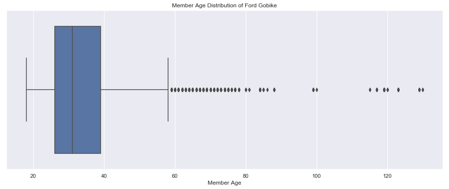

```python
#check the outliers
plt.figure(figsize=(16,6))
sns.boxplot(x='member_age', data=df_clean, orient='h')
plt.title("Member Age Distribution of Ford Gobike")
plt.xlabel("Member Age")
```

Based on the descriptive statistic, 95% of the user are below 60 years old and it was supported by the above chart, we can analyze that member who are more than 60 years old are the outliers of this dataset, thus we dont interest to investigate the outliers. For the purpose of creating age bins, we only interest from age 10 - 60

**Define:**

Few data shows anomaly in member_birth_year, anomaly shows member_birth_year prior 1900. this will be part of the outliers. We would like to remove the outliers which more than 60 years old from the dataset

**Code:**

```python
df_clean = df_clean.query('member_age <= 60')
```

Create bins age for the interested age range only 10-60 years old

```python
#Create bins for age group
df_clean['member_age_group'] = df_clean['member_age'].apply(lambda x: '10 - 20' if 10<x<=20
                                                  else '20 - 30' if 20<x<=30
                                                  else '30 - 40' if 30<x<=40
                                                  else '40 - 50' if 40<x<=50
                                                  else '50 - 60' if 50<x<=60
                                                  else x)
```

```python
df_clean.head(5)
```

|  | duration_sec | start_time | end_time | start_station_id | start_station_name | start_station_latitude | start_station_longitude | end_station_id | end_station_name | end_station_latitude | ... | Unnamed: 16 | duration_min | start_time_hour | end_time_hour | start_time_date | end_time_date | start_time_weekday | end_time_weekday | member_age | member_age_group |
| --- | --- | --- | --- | --- | --- | --- | --- | --- | --- | --- | --- | --- | --- | --- | --- | --- | --- | --- | --- | --- | --- |
| 2 | 33674 | 2019-07-31 22:52:29.791 | 2019-08-01 08:13:44.010 | 2750 | Emeryville Public Market | 37.840521 | -122.293528 | 2750 | Emeryville Public Market | 37.840521 | ... | NaN | 561.233333 | 22 | 8 | 07-31 | 08-01 | Wed | Thu | 34.0 | 30 - 40 |
| 3 | 34546 | 2019-07-31 21:59:34.258 | 2019-08-01 07:35:21.044 | 303 | Golden Gate Ave at Polk St | 37.781270 | -122.418740 | 303 | Pierce St at Haight St | 37.771793 | ... | NaN | 575.766667 | 21 | 7 | 07-31 | 08-01 | Wed | Thu | 31.0 | 30 - 40 |
| 4 | 40244 | 2019-07-31 20:20:37.542 | 2019-08-01 07:31:21.606 | 2637 | Jackson St at 11th St | 37.800002 | -122.266438 | 2637 | 4th Ave at E 12th St (Temporary Location) | 37.795913 | ... | NaN | 670.733333 | 20 | 7 | 07-31 | 08-01 | Wed | Thu | 31.0 | 30 - 40 |
| 6 | 1094 | 2019-07-31 23:58:10.632 | 2019-08-01 00:16:25.594 | 1208 | Snow Park | 37.807813 | -122.264496 | 1208 | Dover St at 57th St | 37.842630 | ... | NaN | 18.233333 | 23 | 0 | 07-31 | 08-01 | Wed | Thu | 50.0 | 40 - 50 |
| 8 | 678 | 2019-07-31 23:56:56.587 | 2019-08-01 00:08:15.528 | 3275 | 3rd St at Townsend St | 37.778742 | -122.392741 | 3275 | Jones St at Post St | 37.787327 | ... | NaN | 11.300000 | 23 | 0 | 07-31 | 08-01 | Wed | Thu | 30.0 | 20 - 30 |

5 rows × 26 columns

**Define:**

In the gender_member, some of Male data is printed as 'M', Female data is printed as 'F', Other data is printed as 'O' and '?'

```python
df_clean['member_gender'].value_counts()
```

```
Male      103688
Female     34569
M          17257
F           4726
Other       2358
O            444
?              0
Name: member_gender, dtype: int64
```

**Code:**

```python
def rep(word):
    if word=='Male':
        return "Male"
    if word=='M':
        return "Male"
    if word=='Female':
        return "Female"
    if word=='F':
        return "Female"
    if word=='Other':
        return "Other"
    if word=='O':
        return "Other"
    if word=='?':
        return "Other"
```

```python
df_clean['member_gender']=df_clean.member_gender.apply(rep)
```

**Test:**

```python
df_clean['member_gender'].value_counts()
```

```
Male      120945
Female     39295
Other       2802
Name: member_gender, dtype: int64
```

**Define:**

Drop the uneccessary column such as start_station_latitude, start_station_longitude, end_station_latitude, end_station_longitude, Unnamed: 16

**Code:**

```python
df_clean.drop(['start_station_latitude' , 'start_station_longitude' , 'end_station_latitude' , 'end_station_longitude','Unnamed: 16'], axis=1 , inplace= True)
```

**Test:**

```python
df_clean.columns
```

```
Index(['duration_sec', 'start_time', 'end_time', 'start_station_id',
       'start_station_name', 'end_station_id', 'end_station_name', 'bike_id',
       'user_type', 'member_birth_year', 'member_gender',
       'bike_share_for_all_trip', 'duration_min', 'start_time_hour',
       'end_time_hour', 'start_time_date', 'end_time_date',
       'start_time_weekday', 'end_time_weekday', 'member_age',
       'member_age_group'],
      dtype='object')
```

```python
df_clean.to_csv('clean_df.csv')
```

## Exploratory Data Analysis

### Part 1: Bike Usage Analysis Based on Time

### Monthly Trend of Bike Usage

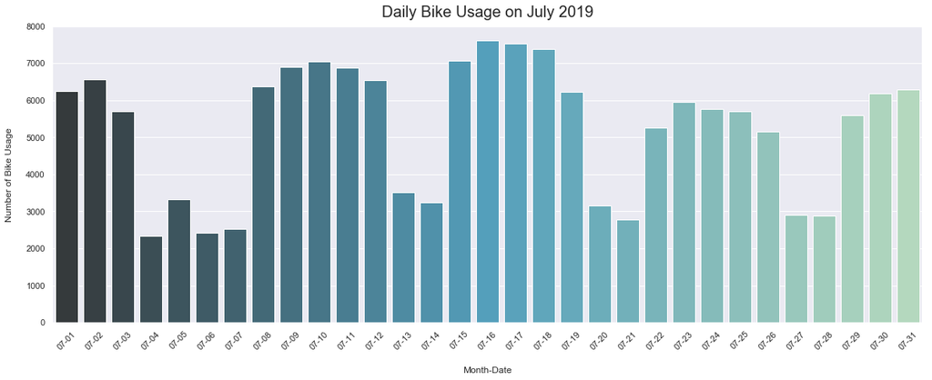

```python
plt.figure(figsize=(20,7))
sns.countplot(x='start_time_date',palette="GnBu_d", data=df_clean.sort_values(by='start_time_date'))
plt.title('Daily Bike Usage on July 2019', fontsize=20, y=1.015)
plt.xlabel('Month-Date', labelpad=20)
plt.ylabel('Number of Bike Usage', labelpad=16)
plt.xticks(rotation = 45)
```

### Weekly Trend of Bike usage - investigate by days

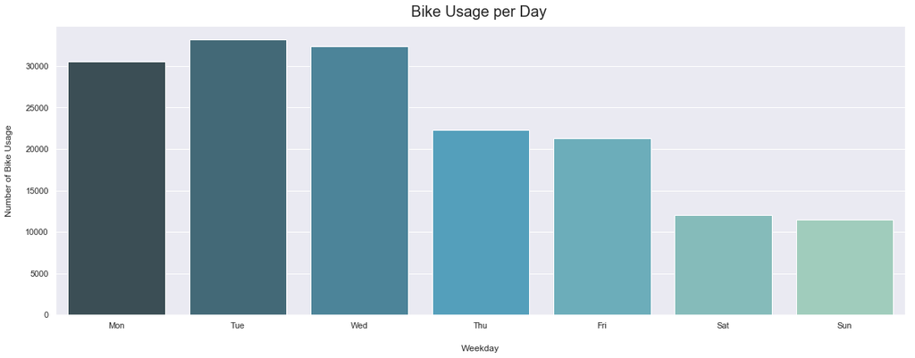

```python
plt.figure(figsize=(20,7))
sns.countplot(x='start_time_weekday',palette = "GnBu_d", data=df_clean.sort_values(by='start_time_date'))
plt.title('Bike Usage per Day ', fontsize=20, y=1.015)
plt.xlabel('Weekday', labelpad=20)
plt.ylabel('Number of Bike Usage', labelpad=16)
```

Based on the above chart, it gives us clarity to see the trend of bike usage in day basis. The trend shows the volume of bike usage is reaching the peak point until Tuesday and start decrease towards weekend (Sunday). Overall, we can conclude that users are likely to use the bike during weekday rather weekend, this might due to people use it to commute to office and school. While during the weekend, people might use for recreational purposes.

### Hourly Trend of Bike Usage

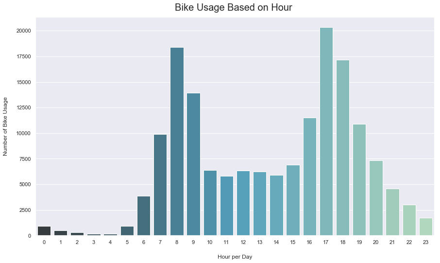

```python
plt.figure(figsize=[14.70, 8.27])
sns.countplot(x='start_time_hour',palette = "GnBu_d", data=df_clean.sort_values(by='start_time_hour'))
plt.title('Bike Usage Based on Hour ', fontsize=20, y=1.015)
plt.xlabel('Hour per Day', labelpad=20)
plt.ylabel('Number of Bike Usage', labelpad=16)
```

Based on the above chart, it shows the peak hours of bike usage can be divided into two period, such as Morning peak-hours and Afternoon peak-hours which are from 7-9a.m and 4-7p.m respectively. This might due to people commute from house to office or school in the morning and inversely during the afternoon.

### Distribution of Bike Usage per Minute Duration

```python
df_clean['duration_min'].describe()
```

```
count    163042.000000
mean         11.838655
std          23.450763
min           1.000000
25%           5.733333
50%           9.050000
75%          13.900000
max        1384.216667
Name: duration_min, dtype: float64
```

```python
#remove outliers based on iqr rule
threshold=(df_clean.duration_min.quantile(0.75) - df_clean.duration_min.quantile(0.25))*1.5
threshold
```

```
12.250000000000002
```

So based on the above IQR Rule, duration that more than 12.25 min would be consider as outlier which we dont interest to investigate

```python
df_nooutlier = df_clean.query('duration_min < (duration_min.quantile(0.75) - duration_min.quantile(0.25))*1.5')
```

```python
df_nooutlier['duration_min'].describe()
```

```
count    111263.000000
mean          6.964975
std           2.789927
min           1.000000
25%           4.733333
50%           6.866667
75%           9.216667
max          12.250000
Name: duration_min, dtype: float64
```

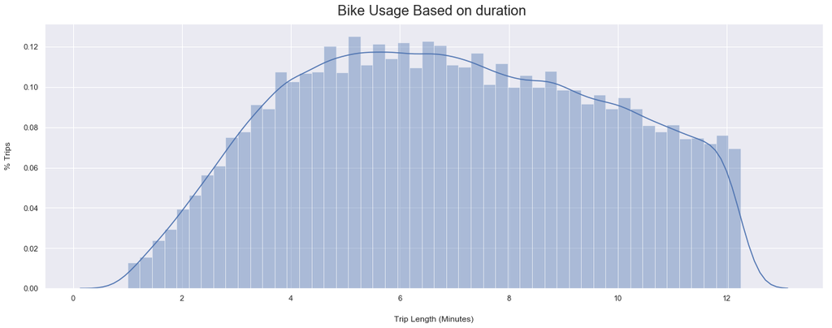

```python
plt.figure(figsize=(20,7))
sns.distplot(df_nooutlier['duration_min'])
plt.title('Bike Usage Based on duration ', fontsize=20, y=1.015)
plt.xlabel('Trip Length (Minutes)', labelpad=20)
plt.ylabel('% Trips', labelpad=16)
```

Based on the dataset that excludes the outliers, the average trip lenght is 6.96 minutes with maximum trip length is 12.25 minutes. This indicates that user is preferred to use bike for short trip range.

Further investigation to find a trend in both weekend and weekday of bike usage based on trip length

```python
#Bivariate exploration
#Create function to distinguish Week_day and Week_end
def week_or_we(day):
    if day in ("Mon","Tue","Wed","Thu", "Fri"):
        return "Week_day"
    else:
        return "Week_end"
```

```python
df_clean['wd_we']=df_clean['start_time_weekday'].apply(week_or_we)
df_clean.head()
```

|  | duration_sec | start_time | end_time | start_station_id | start_station_name | end_station_id | end_station_name | bike_id | user_type | member_birth_year | ... | duration_min | start_time_hour | end_time_hour | start_time_date | end_time_date | start_time_weekday | end_time_weekday | member_age | member_age_group | wd_we |
| --- | --- | --- | --- | --- | --- | --- | --- | --- | --- | --- | --- | --- | --- | --- | --- | --- | --- | --- | --- | --- | --- |
| 2 | 33674 | 2019-07-31 22:52:29.791 | 2019-08-01 08:13:44.010 | 2750 | Emeryville Public Market | 2750 | Emeryville Public Market | 2750 | Customer | 1985.0 | ... | 561.233333 | 22 | 8 | 07-31 | 08-01 | Wed | Thu | 34.0 | 30 - 40 | Week_day |
| 3 | 34546 | 2019-07-31 21:59:34.258 | 2019-08-01 07:35:21.044 | 303 | Golden Gate Ave at Polk St | 303 | Pierce St at Haight St | 303 | Subscriber | 1988.0 | ... | 575.766667 | 21 | 7 | 07-31 | 08-01 | Wed | Thu | 31.0 | 30 - 40 | Week_day |
| 4 | 40244 | 2019-07-31 20:20:37.542 | 2019-08-01 07:31:21.606 | 2637 | Jackson St at 11th St | 2637 | 4th Ave at E 12th St (Temporary Location) | 2637 | Subscriber | 1988.0 | ... | 670.733333 | 20 | 7 | 07-31 | 08-01 | Wed | Thu | 31.0 | 30 - 40 | Week_day |
| 6 | 1094 | 2019-07-31 23:58:10.632 | 2019-08-01 00:16:25.594 | 1208 | Snow Park | 1208 | Dover St at 57th St | 1208 | Subscriber | 1969.0 | ... | 18.233333 | 23 | 0 | 07-31 | 08-01 | Wed | Thu | 50.0 | 40 - 50 | Week_day |
| 8 | 678 | 2019-07-31 23:56:56.587 | 2019-08-01 00:08:15.528 | 3275 | 3rd St at Townsend St | 3275 | Jones St at Post St | 3275 | Subscriber | 1989.0 | ... | 11.300000 | 23 | 0 | 07-31 | 08-01 | Wed | Thu | 30.0 | 20 - 30 | Week_day |

5 rows × 22 columns

```python
wd=df_clean.query('wd_we=="Week_day" & duration_min < (duration_min.quantile(0.75) - duration_min.quantile(0.25))*1.5')
wd.shape
```

```
(96289, 22)
```

```python
we=df_clean.query('wd_we=="Week_end" & duration_min < (duration_min.quantile(0.75) - duration_min.quantile(0.25))*1.5')
we.shape
```

```
(14974, 22)
```

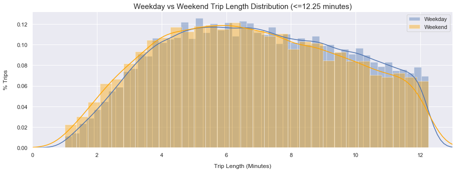

```python
fig, ax = plt.subplots(figsize=(15,5))
sns.distplot(wd.duration_min)
sns.distplot(we.duration_min, color='Orange')
plt.ylabel('% Trips', labelpad=16)
plt.xlabel('Trip Length (Minutes)', labelpad=12)
plt.title('Weekday vs Weekend Trip Length Distribution (<=12.25 minutes)', fontsize = 15)
plt.legend(['Weekday','Weekend'], loc = 1)
plt.xlim(left=0, right=13)
plt.show()
```

By calculating the percentage of trips instead of bike count, it will show a good comparison between bike usage between weekday and weekend. Otherwise, the chart for weekend always be lower since the number of bike usage on weekday is accumulated by 5 days of bike usage. By comparing this two data, it can tell us that there is no significant difference between trip length during weekday and weekend. A slight difference only can be found where trip length in weekend is slightly lower in general, this might due to less congestion during the weekend.

### Part 2: Bike Usage Analysis in Based on Member Age and Gender

### Distribution of Member Age Group

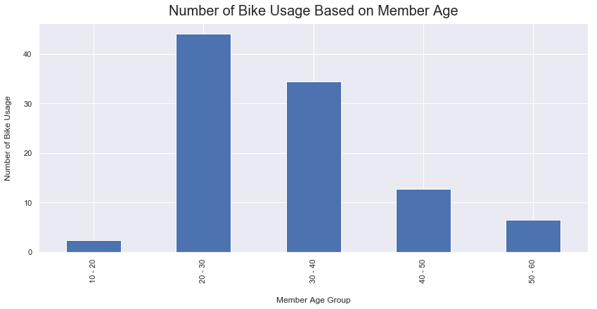

```python
df_age = df_clean.groupby('member_age_group').agg({'bike_id':'count'})

df_age['age_per_of_rides'] = (df_age['bike_id']/df_age['bike_id'].sum())*100
df_age['age_per_of_rides'].plot(kind='bar',figsize=(14,6))

plt.title('Number of Bike Usage Based on Member Age', fontsize=20, y=1.015)
plt.xlabel('Member Age Group', labelpad=20)
plt.ylabel('Number of Bike Usage', labelpad=16)
```

Based on the member age distribution chart, it shows that more than 75% the user are 20-40 years old which is the productive age. This finding might lead to an assumption if the biggest market for bike sharing in San Fransisco Bay Area is those people who are working in the office or student in the college or university. This would be a valuable insight to create a recommendation in marketing strategy

### Distribution of Member Gender

```
(0, 100)
```

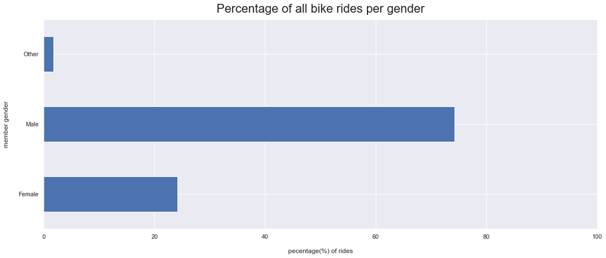

```python
df_gender = df_clean.groupby('member_gender').agg({'bike_id':'count'})

df_gender['per_of_rides'] = (df_gender['bike_id']/df_gender['bike_id'].sum())*100

df_gender['per_of_rides'].plot(kind='barh',figsize=(18,7))
plt.title('Percentage of all bike rides per gender', fontsize=22, y=1.015)
plt.ylabel('member gender', labelpad=16)
plt.xlabel('pecentage(%) of rides', labelpad=16)
plt.xticks(rotation=360)
plt.xlim(0,100)
```

Based on the gender distribution, Male is dominating the bike usage by having more than 70% of population and followed by Female for more than 20%, and the rest belongs to other.

### Weekly Trend of Bike Usage Based on Member Age

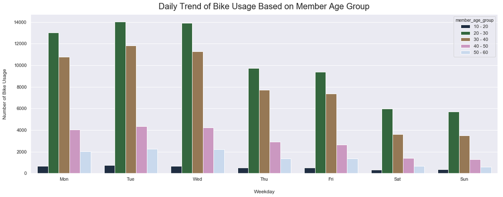

```python
plt.figure(figsize=(20,7))
sns.countplot(x='start_time_weekday', hue='member_age_group',palette = "cubehelix",
                   data=df_clean.sort_values(
                       by=['start_time_date', 'member_age_group']))
plt.title('Daily Trend of Bike Usage Based on Member Age Group', fontsize=20, y=1.015)
plt.xlabel('Weekday', labelpad=20)
plt.ylabel('Number of Bike Usage', labelpad=16)
```

By conducting Bivariate exploration, the above analysis shows that people in age between 20-40 years old are still the biggest market for the whole week regardless weekend or weekday. In general, number of bike usage trend based on daily is decreasing from Wednesday towards weekend and it applies to all age.

### Weekly Trend of Bike Usage Based on Member Gender

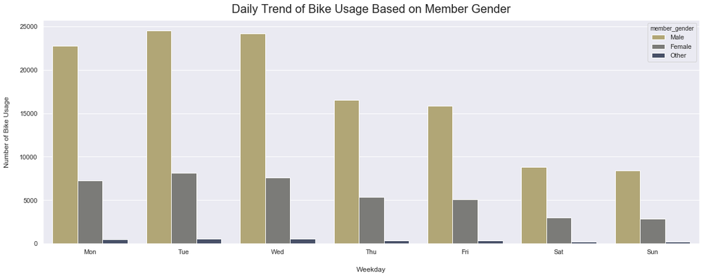

```python
plt.figure(figsize=(20,7))
sns.countplot(x='start_time_weekday', hue='member_gender',palette = "cividis_r",
                   data=df_clean.sort_values(
                       by=['start_time_date',]))
plt.title('Daily Trend of Bike Usage Based on Member Gender', fontsize=20, y=1.015)
plt.xlabel('Weekday', labelpad=20)
plt.ylabel('Number of Bike Usage', labelpad=16)
```

Based on the above bivariate explotation, number of males user are decreasing sharply from Wednesday towards weekend, while female and other gender user decrease gradually

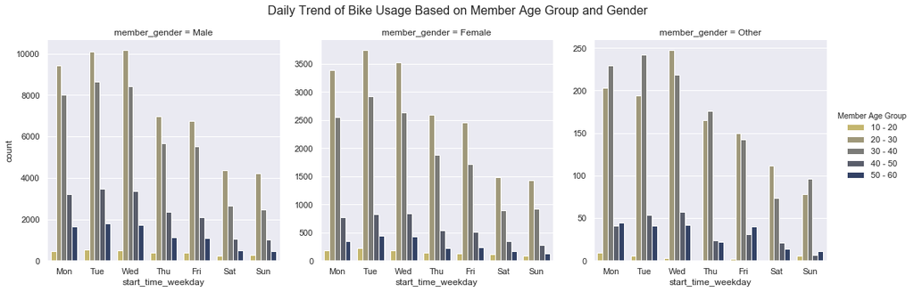

```python
plt.figure(figsize=(12,20))
g=sns.catplot(x='start_time_weekday' , col='member_gender', hue='member_age_group',palette = "cividis_r", kind='count', data=df_clean, hue_order=['10 - 20','20 - 30','30 - 40','40 - 50','50 - 60'], order=['Mon','Tue','Wed','Thu','Fri','Sat','Sun'], sharey=False)
g._legend.set_title('Member Age Group')
g.fig.suptitle("Daily Trend of Bike Usage Based on Member Age Group and Gender",fontsize=16, y=1.05)
```

Based on the above multivariate exploration, Male and Female user gender are having similar trend based on the member age where it is dominated by user with 20-30 years old and followed by 30-40 years old user for the whole of week. In contrast, there are slighly difference for other gender user, for Monday, Tuesday, Thursday and Sunday, user with 30-40 years old are slightly higher than user with 20-30 years old. On the otherhand Wednesday, Friday and Saturday, user with 20-30 years old is slightly higher than 30-40 yeards old. The rest of age member groups are generally similar and do not change significantly.

### Part 3: Bike Usage Analysis in Based on User Type

```
(0, 100)
```

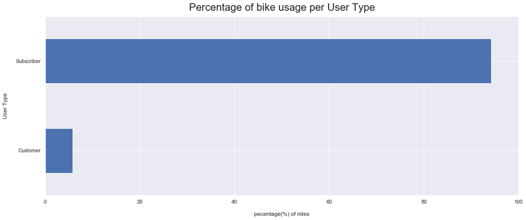

```python
df_user_type = df_clean.groupby('user_type').agg({'bike_id':'count'})

df_user_type['per_of_rides'] = (df_user_type['bike_id']/df_user_type['bike_id'].sum())*100

df_user_type['per_of_rides'].plot(kind='barh', figsize=(18,7))
plt.title('Percentage of bike usage per User Type', fontsize=22, y=1.015)
plt.ylabel('User Type', labelpad=16)
plt.xlabel('pecentage(%) of rides', labelpad=16)
plt.xticks(rotation=360)
plt.xlim(0,100)
```

90% of bike usage is subscriber and the rest are casual user or normal customer. This might a indicator that 90% of the bike sharing user are resident of San Franscisco Bay Area who are living, working, or schooling within the area. While, the normal customer is more likely a tourist and visitor.

### Monthly - Weekly - Hourly Bike Usage Trend Based on User Type

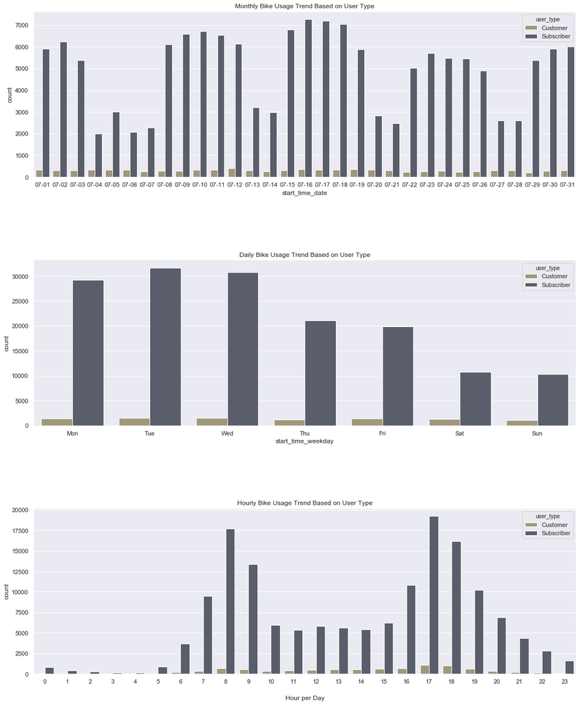

```python
plt.figure()
figure, axes = plt.subplots(3,1)
figure.set_figheight(12)
figure.set_figwidth(10)
plt.subplots_adjust(left=0.125, bottom = 0.1, top = 1.5, right = 1.5, wspace=0.4, hspace=0.5)

#Montly based
sns.countplot(x='start_time_date', hue='user_type',palette = "cividis_r",ax = axes[0],
                   data=df_clean.sort_values(
                       by=['start_time_date'])).set_title('Monthly Bike Usage Trend Based on User Type')
plt.xlabel('Month-Date', labelpad=20)

#Daily based
sns.countplot(x='start_time_weekday', hue='user_type',palette = "cividis_r", ax=axes[1],
                   data=df_clean.sort_values(
                       by=['start_time_date'])).set_title('Daily Bike Usage Trend Based on User Type')
plt.xlabel('Weekday', labelpad=20)

#Hourly Based
sns.countplot(x='start_time_hour', hue='user_type',palette = "cividis_r", ax=axes[2],
                   data=df_clean.sort_values(
                       by=['start_time_date'])).set_title('Hourly Bike Usage Trend Based on User Type')
plt.xlabel('Hour per Day', labelpad=20)
```

From the above three charts, the charts consistently show that Subscriber are taking the biggest portion of the market compared with regular customer disregards the time period (Monthly, Daily and Hourly). In deeper analysis, the trend of bike usage based on regular customer are generaly constant and the fluctuation is not as big as the fluctation in subscriber. The trend of bike usage based on customer reach the peak point during the weekday, especially on Monday, Tuesday, and Wednesday at morning peak hours (7-9 a.m) and afternoon peak hours (4-7 p.m).

### Daily Trend of Bike Usage Based on Member Age Group and User Type

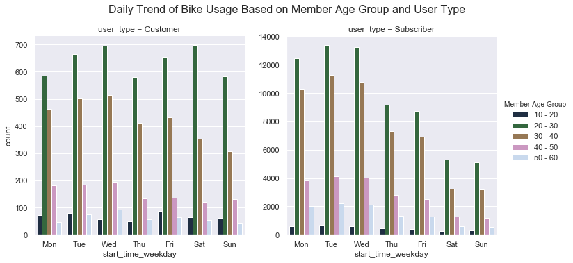

```python
plt.figure(figsize=(12,20))
g=sns.catplot(x='start_time_weekday' , col='user_type', hue='member_age_group',palette = "cubehelix", kind='count', data=df_clean, hue_order=['10 - 20','20 - 30','30 - 40','40 - 50','50 - 60'], order=['Mon','Tue','Wed','Thu','Fri','Sat','Sun'], sharey=False)
g._legend.set_title('Member Age Group')
g.fig.suptitle('Daily Trend of Bike Usage Based on Member Age Group and User Type', fontsize=16, y=1.05)
```

The above chart shows the relationship between bike usage with type of member and member age. the chart shows similar trend with the previous multivariate exploration where bike usage are dominated by users age in between 20-40 years, followed by 40-50 years, 50-60 years, and 10-20 years.

Going deeper in trend of bike usage based customer type, it shows that user with 20-30 years old has sideways trend during the whole week. While the second and third bigger users based on age (30-40 years and 40-50 years) tend to decline towards weekend. This trends is similar with the trend on subscriber trend where all the member age has same trend that number of bike usage is declining towards weekend, start from Wednesday to Sunday.

### Part 4: Requirement of Bike Replenishment During The Peak Hours

For bike replenishment analysis, we only interested in two peak hours periods which are Morning from 7-9 a.m and Afternoon from 4-7 p.m . Each data set will be created for each peak hour periods and followed by calculating the difference in each station by substracting number of bike is leaving (start_station_name) and bike is ariving (end_station_name).

### Morning Peak Hours

```python
#Create another dataframe - make a groupby morning peak hours and afternoon peak hours
#Morning peak hours: 7-9 a.m
df_peak_morning=df_clean.query('start_time_hour==7 or start_time_hour==8 or start_time_hour==9')
df_peak_morning.query('end_time_hour==7 or end_time_hour==8 or end_time_hour==9')
df_peak_morning.head(2)
```

|  | duration_sec | start_time | end_time | start_station_id | start_station_name | end_station_id | end_station_name | bike_id | user_type | member_birth_year | ... | duration_min | start_time_hour | end_time_hour | start_time_date | end_time_date | start_time_weekday | end_time_weekday | member_age | member_age_group | wd_we |
| --- | --- | --- | --- | --- | --- | --- | --- | --- | --- | --- | --- | --- | --- | --- | --- | --- | --- | --- | --- | --- | --- |
| 5085 | 7663 | 2019-07-31 09:11:25.754 | 2019-07-31 11:19:09.063 | 3697 | 24th St at Bartlett St | 3697 | Gennessee St at Monterey Blvd | 3697 | Subscriber | 1973.0 | ... | 127.716667 | 9 | 11 | 07-31 | 07-31 | Wed | Wed | 46.0 | 40 - 50 | Week_day |
| 5230 | 4391 | 2019-07-31 09:19:31.878 | 2019-07-31 10:32:43.349 | 856 | San Francisco Ferry Building (Harry Bridges Pl... | 856 | The Embarcadero at Sansome St | 856 | Subscriber | 1986.0 | ... | 73.183333 | 9 | 10 | 07-31 | 07-31 | Wed | Wed | 33.0 | 30 - 40 | Week_day |

2 rows × 22 columns

```python
#Morning peak hours: 7-9 a.m
#Counting the difference from the bike being taken and bike being return from start station and end station
leaving=df_peak_morning.groupby('start_station_name').size().rename('leaving_bike_count').to_frame()
arriving=df_peak_morning.groupby('end_station_name').size().rename('arriving_bike_count').to_frame()
mor_bike_count=arriving.merge(leaving, left_index=True, right_index=True)
mor_bike_count['difference']=mor_bike_count.leaving_bike_count-mor_bike_count.arriving_bike_count
mor_bike_count.head(2)
```

|  | arriving_bike_count | leaving_bike_count | difference |
| --- | --- | --- | --- |
| 10th Ave at E 15th St | 3 | 21 | 18 |
| 10th St at Fallon St | 178 | 20 | -158 |

### Afternoon Peak Hours

```python
#Afternoon peak hours: 4-7 p.m
df_peak_afternoon=df_clean.query('start_time_hour==16 or start_time_hour==17 or start_time_hour==18 or start_time_hour==19')
df_peak_afternoon.query('end_time_hour==16 or end_time_hour==17 or end_time_hour==18 or end_time_hour==19')
df_peak_afternoon.head(2)
```

|  | duration_sec | start_time | end_time | start_station_id | start_station_name | end_station_id | end_station_name | bike_id | user_type | member_birth_year | ... | duration_min | start_time_hour | end_time_hour | start_time_date | end_time_date | start_time_weekday | end_time_weekday | member_age | member_age_group | wd_we |
| --- | --- | --- | --- | --- | --- | --- | --- | --- | --- | --- | --- | --- | --- | --- | --- | --- | --- | --- | --- | --- | --- |
| 540 | 3177 | 2019-07-31 19:48:04.274 | 2019-07-31 20:41:01.365 | 469 | Ninth St at Heinz Ave | 469 | Lake Merritt BART Station | 469 | Subscriber | 1987.0 | ... | 52.950000 | 19 | 20 | 07-31 | 07-31 | Wed | Wed | 32.0 | 30 - 40 | Week_day |
| 552 | 2404 | 2019-07-31 19:59:02.885 | 2019-07-31 20:39:07.613 | 2855 | Madison St at 17th St | 2855 | Union St at 10th St | 2855 | Subscriber | 1992.0 | ... | 40.066667 | 19 | 20 | 07-31 | 07-31 | Wed | Wed | 27.0 | 20 - 30 | Week_day |

2 rows × 22 columns

```python
#Afternoon peak hours: 4-7 p.m
#Counting the difference from the bike being taken and bike being return from start station and end station
leaving=df_peak_afternoon.groupby('start_station_name').size().rename('leaving_bike_count').to_frame()
arriving=df_peak_afternoon.groupby('end_station_name').size().rename('arriving_bike_count').to_frame()
aft_bike_count=arriving.merge(leaving, left_index=True, right_index=True)
aft_bike_count['difference']=aft_bike_count.leaving_bike_count-aft_bike_count.arriving_bike_count
aft_bike_count.head(2)
```

|  | arriving_bike_count | leaving_bike_count | difference |
| --- | --- | --- | --- |
| 10th Ave at E 15th St | 16 | 9 | -7 |
| 10th St at Empire St | 13 | 4 | -9 |

#### Requirement of Bike Replenishment during the Morning Peak Hours

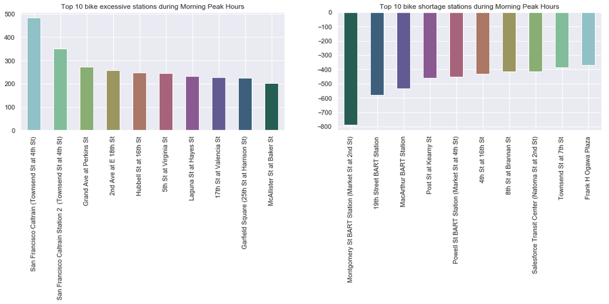

```python
#Morning peak hours: 7-9 a.m
#ploting bike excessive and shortage stations during morning peak hours
plt.figure()
figure, axes = plt.subplots(1,2)
figure.set_figheight(2)
figure.set_figwidth(10)
plt.subplots_adjust(left=0.125, bottom = 0.1, top = 1.5, right = 1.5, wspace=0.2, hspace=0.5)

#Bike shortage
mor_shortage = mor_bike_count ['difference'].nsmallest(10).plot(kind='bar', ax=axes[1], color = sns.cubehelix_palette(10, start=0, rot=2.6, dark=0.7, light=.3, reverse=False)).set_title('Top 10 bike shortage stations during Morning Peak Hours')

#Bike excessive
mor_excess= mor_bike_count['difference'].nlargest(10).plot(kind='bar', ax=axes[0], color = sns.cubehelix_palette(10, start=0, rot=2.6, dark=0.7, light=.3, reverse=True)).set_title('Top 10 bike excessive stations during Morning Peak Hours')
```

For Morning Peak Hours, these are recommendation for stations that need to be replenished based on the prioritization:

**From:**

1. San Francisco Caltrain (Townsend St at 4th St)
2. San Francisco Caltrain Station 2 (Townsend St at 4th St)
3. Grand Ave At Perkins St
4. 2nd Ave at E 18th St
5. Hubbell St at 16th St

**To:**

1. Montgomery St BART Station (Market St at 2nd St)
2. 19th Street BART Station
3. MacArthur BART Station
4. Post St at Keanny St
5. Powell St BART Station (Market St at 4th St)

#### Requirement of Bike Replenishment during the Afternoon Peak Hours

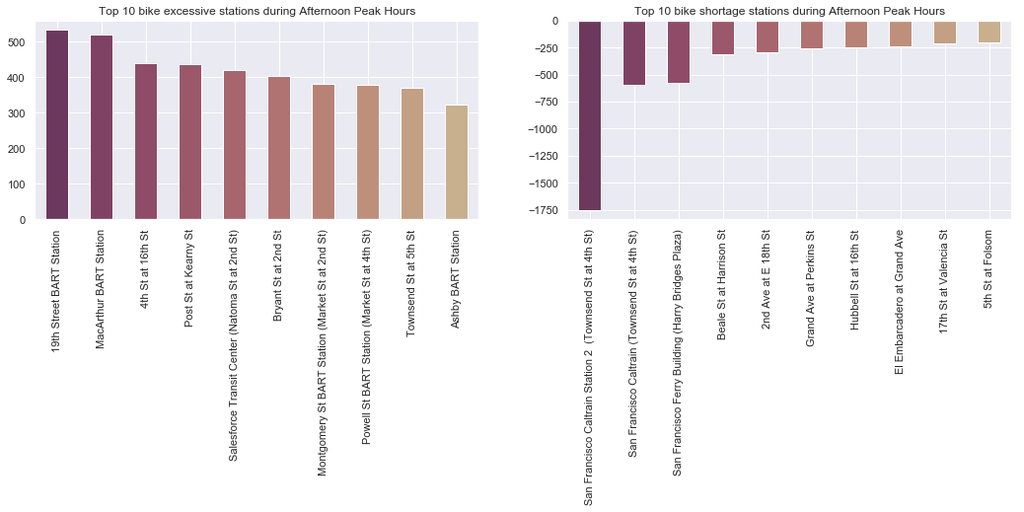

```python
# peak hours: 7-9 a.m
#ploting bike excessive and shortage stations during afternoon peak hours
plt.figure()
figure, axes = plt.subplots(1,2)
figure.set_figheight(2)
figure.set_figwidth(10)
plt.subplots_adjust(left=0.125, bottom = 0.1, top = 1.5, right = 1.5, wspace=0.2, hspace=0.5)

#Afternoon Bike shortage
aft_shortage = aft_bike_count['difference'].nsmallest(10).plot(kind='bar', ax=axes[1], color = sns.cubehelix_palette(10, start=0, rot=.6, dark=0.7, light=.3, reverse=False)).set_title('Top 10 bike shortage stations during Afternoon Peak Hours')

#Afternoon Bike excessive
aft_excess= aft_bike_count['difference'].nlargest(10).plot(kind='bar', ax=axes[0], color = sns.cubehelix_palette(10, start=0, rot=.6, dark=0.7, light=.3, reverse=False)).set_title('Top 10 bike excessive stations during Afternoon Peak Hours')
```

```python
mor_bike_count.to_csv('mor_bike_count.csv')
```

```python
aft_bike_count.to_csv('aft_bike_count.csv')
```

For Afternoon Peak Hours, these are recommendation for stations that need to be replenished based on the prioritization:

**From:**

1. 19th Street BART Station
2. MacArthur BART Station
3. 4th St at 16th St
4. Post St at Keanny St
5. Salesforce Transit Center (Natoma St at 2nd St)

**To:**

1. San Francisco Caltrain Station 2 (Townsend St at 4th St)
2. San Francisco Caltrain (Townsend St at 4th St)
3. San Francisco Ferry Building (Harry Birdges Plaza)

(Note: Due to the large bike shortage number in San Francisco Caltrain Station 2, the prioritization of bike replenishment is only made in those 3 stations by considering the balance of bike excessive and shortage)

## Summary

Based on the above analysis, here are the summary and recommendation:

### Part 2: Bike Usage Analysis in Based on Member Age and Gender

- Based on the member age distribution chart, it shows that more than 75% the user are 20-40 years old which is the productive age. This finding might lead to an assumption if the biggest market for bike sharing in San Fransisco Bay Area is those people who are working in the office or student in the college or university. This would be a valuable insight to create a recommendation in marketing strategy
- Based on the gender distribution, Male is dominating the bike usage by having more than 70% of population and followed by Female for more than 20%, and the rest belongs to other.
- By conducting Bivariate exploration, the above analysis shows that people in age between 20-40 years old are still the biggest market for the whole week regardless weekend or weekday. In general, number of bike usage trend based on daily is decreasing from Wednesday towards weekend and it applies to all age.
- Based on the above bivariate explotation, number of males user are decreasing sharply from Wednesday towards weekend, while female and other gender user decrease gradually
- Based on the above multivariate exploration, Male and Female user gender are having similar trend based on the member age where it is dominated by user with 20-30 years old and followed by 30-40 years old user for the whole of week. In contrast, there are slighly difference for other gender user, for Monday, Tuesday, Thursday and Sunday, user with 30-40 years old are slightly higher than user with 20-30 years old. On the otherhand Wednesday, Friday and Saturday, user with 20-30 years old is slightly higher than 30-40 yeards old. The rest of age member groups are generally similar and do not change significantly.

### Part 3: Bike Usage Analysis in Based on User Type

- 90% of bike usage is subscriber and the rest are casual user or normal customer. This might a indicator that 90% of the bike sharing user are resident of San Franscisco Bay Area who are living, working, or schooling within the area. While, the normal customer is more likely a tourist and visitor.
- From the above three charts, the charts consistently show that Subscriber are taking the biggest portion of the market compared with regular customer disregards the time period (Monthly, Daily and Hourly). In deeper analysis, the trend of bike usage based on regular customer are generaly constant and the fluctuation is not as big as the fluctation in subscriber. The trend of bike usage based on customer reach the peak point during the weekday, especially on Monday, Tuesday, and Wednesday at morning peak hours (7-9 a.m) and afternoon peak hours (4-7 p.m).
- The above chart shows the relationship between bike usage with type of member and member age. the chart shows similar trend with the previous multivariate exploration where bike usage are dominated by users age in between 20-40 years, followed by 40-50 years, 50-60 years, and 10-20 years. Going deeper in trend of bike usage based customer type, it shows that user with 20-30 years old has sideways trend during the whole week. While the second and third bigger users based on age (30-40 years and 40-50 years) tend to decline towards weekend. This trends is similar with the trend on subscriber trend where all the member age has same trend that number of bike usage is declining towards weekend, start from Wednesday to Sunday.

### Part 4: Requirement of Bike Replenishment During The Peak Hours

For Morning Peak Hours, these are recommendation for stations that need to be replenished based on the prioritization:

**From:**

1. San Francisco Caltrain (Townsend St at 4th St)
2. San Francisco Caltrain Station 2 (Townsend St at 4th St)
3. Grand Ave At Perkins St
4. 2nd Ave at E 18th St
5. Hubbell St at 16th St

**To:**

1. Montgomery St BART Station (Market St at 2nd St)
2. 19th Street BART Station
3. MacArthur BART Station
4. Post St at Keanny St
5. Powell St BART Station (Market St at 4th St)

For Afternoon Peak Hours, these are recommendation for stations that need to be replenished based on the prioritization:

**From:**

1. 19th Street BART Station
2. MacArthur BART Station
3. 4th St at 16th St
4. Post St at Keanny St
5. Salesforce Transit Center (Natoma St at 2nd St)

**To:**

1. San Francisco Caltrain Station 2 (Townsend St at 4th St)
2. San Francisco Caltrain (Townsend St at 4th St)
3. San Francisco Ferry Building (Harry Birdges Plaza)

*(Note: Due to the large bike shortage number in San Francisco Caltrain Station 2, the prioritization of bike replenishment is only made in those 3 stations by considering the balance of bike excessive and shortage)*

## Limitation

1. Distance between station to another station is not investigated in this project since it requeries further study about San Fransisco Map. Therefore, the data about longitude and latitude was dropped since it is not relevant to this project
2. Further mapping studies are also required to optimize the bike replenishment recommendation by considering distance from 1 station to another station and also congestion data would be an important information.